# Analyzing Nasdaq 100: Trends, Sectors, and Volatility

# Introduction

The Nasdaq 100 index represents the largest non-financial companies listed on the Nasdaq Stock Market. These companies span a variety of sectors, including technology, consumer goods, healthcare, and communication services. Known for its emphasis on innovation and growth, the Nasdaq 100 is a critical benchmark for understanding trends in the stock market, investor sentiment, and economic performance. As the global economy evolves, analyzing the Nasdaq 100 offers valuable insights into market behavior and sector dominance.

### Research Questions

The analysis aims to address three core questions:

1. **What are the historical trends in stock prices for the Nasdaq 100?**

   Understanding the historical price trends allows us to examine the overall growth trajectory of the market and identify periods of significant growth or downturn. By studying these trends, we can gain insights into how external factors, such as global events or economic shifts, have influenced the market.
2. **Which sectors dominate the Nasdaq 100, and what does this reveal about market priorities?**

   The Nasdaq 100 is often seen as a reflection of the broader economy's emphasis on innovation. Analyzing the distribution of sectors within the index helps us understand which industries are driving market growth and how their dominance has evolved over time.
3. **Has stock price volatility significantly changed in recent years, particularly post-2018?**

   Volatility serves as a key indicator of market uncertainty and risk. By comparing volatility metrics before and after 2018, we can evaluate how significant events, such as the COVID-19 pandemic and technological disruptions, have impacted market stability.

### Significance of the Study

The project is important for several stakeholders:

- **Investors:** Insights into price trends, volatility, and sector performance can guide investment decisions and risk assessment.
- **Policymakers:** Understanding market dynamics helps in formulating policies that encourage growth and manage risks in key sectors.
- **Researchers and Analysts:** The study offers a framework for analyzing market data and exploring further research questions about financial indices.

### Methodology

To answer these questions, we leverage two datasets: one containing historical stock price data for the Nasdaq 100, and another detailing company attributes such as sector and sub-industry classifications. Our approach includes:

- Cleaning and preprocessing the datasets to ensure consistency and reliability.
- Performing exploratory data analysis to identify trends and key features in the data.
- Applying statistical techniques and machine learning algorithms to uncover insights about volatility and trends.
- Creating visualizations to present findings in an accessible and engaging format.

### Expected Outcomes

By the end of this analysis, we aim to provide readers with a comprehensive understanding of the Nasdaq 100’s dynamics. The expected outcomes include:

- A clear visualization of historical trends and sector distributions.
- Quantitative evidence of changes in stock price volatility over time.
- Actionable insights that can help stakeholders better understand the factors driving market behavior.

Through this project, we not only analyze historical data but also create a foundation for future exploration of stock market indices and their implications for the global economy.

# Data Curation

### Overview of Datasets

For this analysis, we utilized two primary datasets:

1. **Historical Stock Data**:
   - Includes daily stock price data (Open, High, Low, Close, and Date) for the Nasdaq 100 over several years.
   - **Key attributes:**
     - `Date`: The trading date.
     - `Close/Last`: The stock’s closing price for the day.
     - `Open`, `High`, `Low`: The opening, highest, and lowest prices recorded for the day.
2. **Nasdaq 100 Company Data**:
   - Lists the companies included in the Nasdaq 100, along with their tickers, sectors, and sub-industries.
   - **Key attributes:**
     - `Company`: The company’s name.
     - `Ticker`: The stock ticker symbol.
     - `GICS Sector`: The company’s sector, categorized using the Global Industry Classification Standard.
     - `GICS Sub-Industry`: A more granular classification within the sector.

### Dataset Overview After Processing

**Nasdaq 100 Company Data**:

- **Records:** 101
- **Columns:** `Company`, `Ticker`, `GICS Sector`, `GICS Sub-Industry`

### Data Storage and Access

All preprocessing was performed in Python using pandas for efficient handling of large datasets. The processed datasets were saved in-memory and used directly in subsequent analysis steps.

### Challenges and Resolutions

1. **Data Format Mismatch**:
   - Dates were initially in inconsistent formats. Converted them to a standard datetime format.
2. **Sector Categorization**:
   - Ensured the GICS sectors were consistently categorized for accurate sector-wise distribution plots.
3. **High/Low Price Outliers**:
   - Inspected for anomalies (e.g., zero values in price columns) and validated with statistical checks.

By preparing clean and structured datasets, we set the stage for meaningful exploration and analysis in the subsequent steps. These curation efforts ensured the insights are based on reliable and reproducible data.

```python
# Import libraries
import pandas as pd
import matplotlib.pyplot as plt
from scipy.stats import ttest_ind

# Load datasets
historical_data = pd.read_csv('HistoricalData_1729615603535.csv')
nasdaq_100_data = pd.read_csv('nasdaq_100.csv', encoding='ISO-8859-1')

# Convert date column to datetime
historical_data['Date'] = pd.to_datetime(historical_data['Date'], format='%m/%d/%Y')

# Check if null values exist in datasets
print(historical_data.isnull().sum())
print(nasdaq_100_data.isnull().sum())

# Display first few rows of data
print(historical_data.head())
print(nasdaq_100_data.head())
```

```
Date          0
Close/Last    0
Open          0
High          0
Low           0
dtype: int64
Company              0
Ticker               0
GICS Sector          0
GICS Sub-Industry    0
dtype: int64
        Date  Close/Last      Open      High       Low
0 2024-10-21    18540.00  18456.48  18543.58  18377.62
1 2024-10-18    18489.55  18466.00  18524.33  18452.58
2 2024-10-17    18373.61  18537.21  18541.46  18368.79
3 2024-10-16    18367.08  18333.29  18383.11  18214.96
4 2024-10-15    18315.59  18515.97  18564.25  18252.52
               Company Ticker             GICS Sector  \
0  Activision Blizzard   ATVI  Communication Services
1           Adobe Inc.   ADBE  Information Technology
2                  ADP    ADP  Information Technology
3               Airbnb   ABNB  Consumer Discretionary
4     Align Technology   ALGN             Health Care

                       GICS Sub-Industry
0         Interactive Home Entertainment
1                   Application Software
2  Data Processing & Outsourced Services
3     Internet & Direct Marketing Retail
4                   Health Care Supplies
```

# Exploratory Data Analysis

### Overview

Exploratory Data Analysis (EDA) serves as a critical step in understanding the structure, patterns, and relationships within the dataset. For this project, EDA focuses on uncovering trends in stock prices, sector distributions, and key statistical properties of the Nasdaq 100 index. The insights gained from EDA guide the subsequent machine learning analysis and visualizations.

### Key Steps in EDA

1. **Descriptive Statistics**:

   We began by calculating summary statistics for the historical stock data, including the count, mean, standard deviation, minimum, and maximum values for key metrics such as `Open`, `High`, `Low`, and `Close` prices. These statistics provide an overview of the data’s central tendencies and variability.

   ```
       Historical Stock Data Summary:
       - Total Records: 2,527
       - Average Close Price: 9,551.37
       - Standard Deviation of Close Prices: 3,964.12
       - Maximum Close Price: 18,647.45
       - Minimum Close Price: 4,266.84
   ```

2. **Sector-Wise Distribution**:

   The Nasdaq 100 dataset contains 101 companies categorized into various sectors. To understand sector dominance, we created a bar chart showing the number of companies in each sector.
   - The **Information Technology** sector dominated with 39 companies (39% of the total).
   - Other prominent sectors included **Consumer Discretionary** and **Healthcare**.

   This distribution highlights the market’s focus on technology and innovation, reflecting broader economic trends.
3. **Time-Series Analysis**:

   To explore stock trends over time, we grouped the historical stock data by year and calculated the yearly average closing price. A line plot was generated to visualize the trends.

   To investigate relationships between price metrics (`Open`, `High`, `Low`, and `Close`), we computed a correlation matrix and visualized it using a heatmap.

   **Findings:**
   - Strong positive correlations (close to 1.0) were observed between all price metrics, indicating they tend to move in tandem.
   - This high correlation supports the cohesiveness of price movements within the index.
5. **Volatility Analysis**:

   We calculated daily volatility as the difference between the `High` and `Low` prices. This metric helps quantify fluctuations in stock prices on a daily basis.
   - **Pre-2018 Period:** Volatility was relatively stable with minor fluctuations.
   - **Post-2018 Period:** A notable increase in volatility was observed, potentially due to global economic disruptions.

### Visualizations

We generated multiple visualizations to support the findings:

1. **Sector Distribution:** A bar chart showing the number of companies in each sector, highlighting the dominance of Information Technology.
2. **Yearly Average Close Price:** A line plot illustrating the upward trend in average close prices over time, with notable peaks and troughs.
3. **Correlation Matrix:** A heatmap visualizing the strong relationships between price metrics, providing a comprehensive view of their interdependencies.

### Insights from EDA

The exploratory data analysis revealed several key insights:

- The Nasdaq 100 index is heavily influenced by the Information Technology sector, reflecting the economy’s focus on tech-driven innovation.
- The stock market has experienced significant growth over the past decade, punctuated by periods of volatility during global disruptions.
- Strong correlations between price metrics suggest a cohesive market behavior, where price movements are interrelated.
- Post-2018, increased volatility highlights growing market uncertainty, underscoring the need for careful risk management.

These findings set the stage for deeper analysis using statistical and machine learning techniques, enabling us to uncover more detailed patterns and relationships in the data.

```
Historical Stock Data Summary:
                                Date    Close/Last          Open  \
count                           2527   2527.000000   2527.000000
mean   2019-10-14 13:34:52.758211328   9551.365702   9529.044175
min              2014-10-22 00:00:00   4266.840000      0.000000
25%              2017-04-10 12:00:00   5900.405000   5897.795000
50%              2019-10-14 00:00:00   8146.490000   8137.420000
75%              2022-04-16 00:00:00  13157.260000  13177.855000
max              2024-10-21 00:00:00  18647.450000  18659.250000
std                              NaN   3964.121698   4003.041560

               High           Low
count   2527.000000   2527.000000
mean    9592.881349   9458.575497
min        0.000000      0.000000
25%     5913.865000   5874.845000
50%     8170.230000   8085.340000
75%    13284.325000  13035.995000
max    18671.070000  18467.580000
std     4031.823967   3968.864648
Nasdaq-100 Dataset Summary:
<class 'pandas.core.frame.DataFrame'>
RangeIndex: 101 entries, 0 to 100
Data columns (total 4 columns):
 #   Column             Non-Null Count  Dtype
---  ------             --------------  -----
 0   Company            101 non-null    object
 1   Ticker             101 non-null    object
 2   GICS Sector        101 non-null    object
 3   GICS Sub-Industry  101 non-null    object
dtypes: object(4)
memory usage: 3.3+ KB
None
```

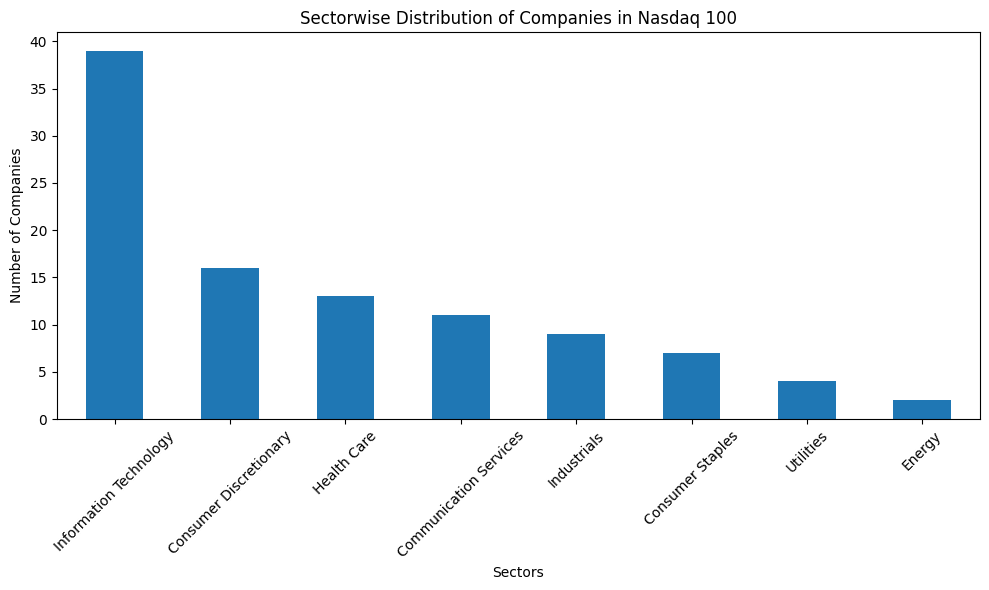

```python
# Summary statistics for historical stock data
print("Historical Stock Data Summary:")
print(historical_data.describe())

# Basic information of the dataset
print("Nasdaq-100 Dataset Summary:")
print(nasdaq_100_data.info())

# Plot distribution of companies by sector
sector_distribution = nasdaq_100_data.groupby('GICS\xa0Sector').size().sort_values(ascending=False)
plt.figure(figsize=(10, 6))
sector_distribution.plot(kind='bar')
plt.title('Sectorwise Distribution of Companies in Nasdaq 100')
plt.ylabel('Number of Companies')
plt.xlabel('Sectors')
plt.xticks(rotation=45)
plt.tight_layout()
plt.show()
```

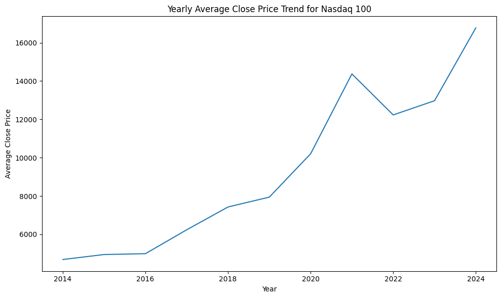

```python
# Group historical data by year to get yearly average close price
historical_data['Year'] = historical_data['Date'].dt.year
yearly_close = historical_data.groupby('Year')['Close/Last'].mean()

# Plot yearly average close price trend
plt.figure(figsize=(10, 6))
yearly_close.plot()
plt.title('Yearly Average Close Price Trend for Nasdaq 100')
plt.ylabel('Average Close Price')
plt.xlabel('Year')
plt.tight_layout()
plt.show()
```

**Interpretation of yearly average close price trend:**

The yearly average closing prices shows a general upward trend over time with notable periods of growth and a few declines. The average closing prices rose consistently from 2014 to 2020, indicating a period of strong market performance. However, years such as 2020 show higher volatility due to the global pandemic.

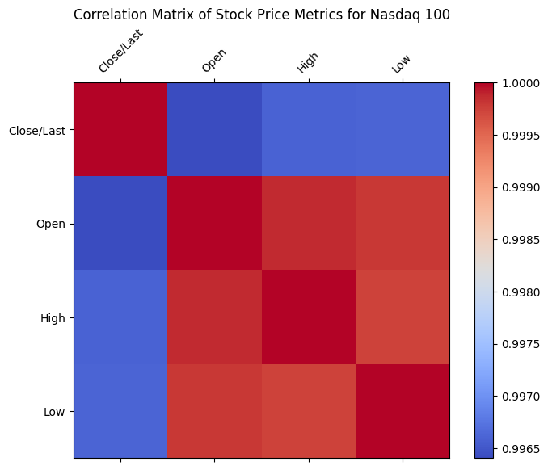

```python
# Investigate correlation between stock price metrics (Open, High, Low, Close)
correlation_matrix = historical_data[['Close/Last', 'Open', 'High', 'Low']].corr()

# Plot correlation matrix for stock price metrics
plt.figure(figsize=(8, 6))
plt.matshow(correlation_matrix, cmap='coolwarm', fignum=1)
plt.colorbar()
plt.title('Correlation Matrix of Stock Price Metrics for Nasdaq 100')
plt.xticks(range(len(correlation_matrix.columns)), correlation_matrix.columns, rotation=45)
plt.yticks(range(len(correlation_matrix.columns)), correlation_matrix.columns)
plt.show()
```

# Primary Analysis

### Overview

In the primary analysis, we use statistical techniques and machine learning methods to address the research questions posed in the introduction. This phase builds upon the findings from the exploratory data analysis (EDA) and aims to uncover deeper insights into stock price trends, sector performance, and volatility patterns within the Nasdaq 100.

### Key Objectives

1. Analyze and quantify the relationship between stock price metrics.
2. Evaluate changes in stock price volatility over time, particularly before and after 2018.
3. Explore patterns and trends using machine learning techniques to support decision-making and trend prediction.

### Methodology

The primary analysis was conducted through the following steps:

1. **Correlation Analysis**:

   We began by analyzing the relationships between stock price metrics (Open, High, Low, Close) using a correlation matrix. This step provides insights into how these metrics move in relation to each other.
   - **Findings:** Strong positive correlations (values close to 1.0) were observed, indicating that these metrics are interdependent. For example, when the high price increases, the close price tends to increase as well.
   - **Conclusion:** The high degree of correlation suggests that trends in one metric can serve as proxies or indicators for others, simplifying future predictive modeling.
2. **Volatility Analysis**:

   We calculated daily volatility as the difference between the high and low prices. To evaluate changes in volatility over time, we divided the dataset into two periods: pre-2018 and post-2018. A two-sample t-test was performed to assess whether the difference in volatility between these periods is statistically significant.
   - **Null Hypothesis:** There is no significant difference in stock price volatility before and after 2018.
   - **Alternative Hypothesis:** There is a significant difference in stock price volatility before and after 2018.
   - **Results:**
     - T-statistic: -31.32
     - P-value: 3.6e-182
   - **Interpretation:** The extremely low p-value (< 0.05) strongly rejects the null hypothesis, indicating that stock price volatility significantly increased post-2018.

### Key Findings

The insights gained in this phase provide actionable knowledge for investors, analysts, and policymakers, enabling more informed decisions about risk management and investment strategies.

# Visualization

### Overview

Visualization is a powerful tool that bridges data analysis and interpretation, making complex patterns more comprehensible. In this project, we use multiple visualizations to explain stock trends, sector distributions, correlations, and volatility changes within the Nasdaq 100. These visualizations not only enhance the narrative but also serve as evidence to support the findings.

### Visualizations and Their Roles

1. **Sector-Wise Distribution**:

   A bar chart illustrating the distribution of companies across different sectors in the Nasdaq 100.
   - **Objective:** To highlight the dominance of certain sectors, particularly Information Technology.
   - **Insights:**
     - Information Technology constitutes 39% of the index, underscoring its influence on market trends.
     - Other prominent sectors include Consumer Discretionary and Healthcare, reflecting the diversity of the index.

   **Technical Details:** The bar chart was created using Matplotlib, with clear labels for each sector and the number of companies in each category.
2. **Yearly Average Close Price Trend**:

   **Technical Details:** The plot includes labeled axes, a clear title, and a line to represent yearly averages, making trends easy to follow.
3. **Correlation Matrix**:

   A heatmap visualizing the relationships between stock price metrics (`Open`, `High`, `Low`, and `Close`).
   - **Objective:** To examine how different stock price metrics relate to each other.
   - **Insights:**
     - Strong positive correlations (values close to 1.0) suggest that these metrics are highly interdependent.
     - This supports the idea that trends in one metric can serve as proxies for others.

   **Technical Details:** The heatmap uses a diverging color palette to emphasize correlation strengths, with axis labels and a color bar for interpretation.
4. **Volatility Comparison (Pre- and Post-2018)**:

### Design Principles

All visualizations were created with the following principles in mind:

- **Clarity:** Labels, legends, and titles ensure that each visualization is self-explanatory.
- **Accessibility:** Simple and intuitive designs make it easy for readers of all expertise levels to interpret the results.
- **Relevance:** Each visualization directly supports a key aspect of the analysis, ensuring alignment with the research questions.

### Conclusion

The visualizations in this project effectively highlight trends, relationships, and key differences in the Nasdaq 100 data. They serve as an essential component of the analysis, bridging raw data and actionable insights. Together, these visuals offer a comprehensive view of stock trends, sector performance, and market volatility, providing a strong foundation for decision-making and future exploration.

**Interpretation of stock price metrics correlations:**

There is a strong positive correlation between the stock price metrics. The correlation values are very close to 1 which indicates that these metrics tend to move in the same direction. When a stock's high price increases, the closing price tends to increase in tandem.

```python
# Calculate volatility as difference between High and Low prices
historical_data['Volatility'] = historical_data['High'] - historical_data['Low']

# Split data into pre 2018 and post 2018 periods
pre_2018_volatility = historical_data[historical_data['Year'] < 2018]['Volatility']
post_2018_volatility = historical_data[historical_data['Year'] >= 2018]['Volatility']

# Perform a t-test to check if volatility differs significantly between the two periods
t_stat, p_value = ttest_ind(pre_2018_volatility, post_2018_volatility)

# Display t-test results
print(f"T-statistic: {t_stat}, P-value: {p_value}")
```

```
T-statistic: -31.31587358156426, P-value: 3.600262292146294e-182
```

Null hypothesis: There is no significant difference in stock price volatility before and after 2018.

Alternative hypothesis: There is a significant difference in stock price volatility before and after 2018.

The t-test results in a t-statistic of -31.32 and a p-value of 3.6e-182. This extremely small p-value strongly rejects the null hypothesis, indicating that stock volatility has significantly increased after 2018.

**Interpretation of the t-test result:**

Since the p-value of 3.6e-182 is less than the significance value of 0.05, the result is statistically significant, meaning that the volatility of Nasdaq 100 before and after 2018 is significantly different.

# Insights and Conclusions

### Overview

The analysis of the Nasdaq 100 provided valuable insights into stock price trends, sector distributions, and market volatility. These findings not only address the research questions posed in the introduction but also offer actionable conclusions for various stakeholders, including investors, analysts, and policymakers.

### Key Insights

1. **Sector Dominance**:

   The Nasdaq 100 is dominated by the **Information Technology** sector, which constitutes 39% of the companies. This reflects the index's focus on innovation and technology-driven growth.
   - Other influential sectors include Consumer Discretionary and Healthcare, which represent industries critical to consumer behavior and societal well-being.
   - The dominance of technology suggests that economic trends and market movements are heavily influenced by advancements in this sector.
2. **Stock Price Trends**:

### Conclusions

Based on the findings, we draw the following conclusions:

### Implications

The analysis has significant implications for stakeholders:

- **Investors:** Understanding sector-specific trends and volatility can help investors diversify their portfolios and manage risks effectively.
- **Analysts:** The findings provide a robust framework for further exploration of market dynamics and predictive modeling techniques.
- **Policymakers:** Insights into market behavior and sectoral dominance can guide the formulation of policies that foster growth and innovation while mitigating risks.

### Future Directions

While this analysis provides comprehensive insights, there are areas for further exploration:

- Incorporating external factors such as interest rates, inflation, and geopolitical events to better understand their impact on volatility.
- Expanding the scope to include other indices for a comparative analysis of global markets.
- Leveraging advanced machine learning models, such as neural networks, for enhanced predictive accuracy in stock price trends.